# Harsh Pithadia_Final

hp621@scarletmail.rutgers.edu

12/04/2023

```r
#Importing library
library(fpp)
library(fpp2)
```

```r
library(ggplot2)
library(xts)
library(forecast)

# Used to convert scientific numbers into normal numeric numbers
options(scipen = 999)
```

#Introduction ##Yahoo Finance is a comprehensive financial platform provided by Yahoo that offers a wide range of information related to the financial markets. It covers various aspects, including stock prices, market news, company profiles, financial statements, and commodity prices, such as gold. The platform is widely used by investors, traders, and individuals interested in staying informed about the latest developments in the financial world. Users can access real-time data, historical charts, and other tools to analyze and track the performance of different assets. Yahoo Finance aims to provide a user-friendly interface for individuals to make informed decisions about their investments and stay updated on market trends. In this case, we consider the monthly closing Gold Prices over the past 5 years.

##Import the data

```r
library(readr)
GOLD <- read_csv("C://Users//HARSH//Desktop//RU//BF//finals//GLD_Final.csv")
```

```
## ──────────────────────────────────────────────────────── Delimiter: "," dbl
## (1): Close lgl (2): ...3, ...4 date (1): Date
```

```r
View(GOLD)
```

## Plot and Inference

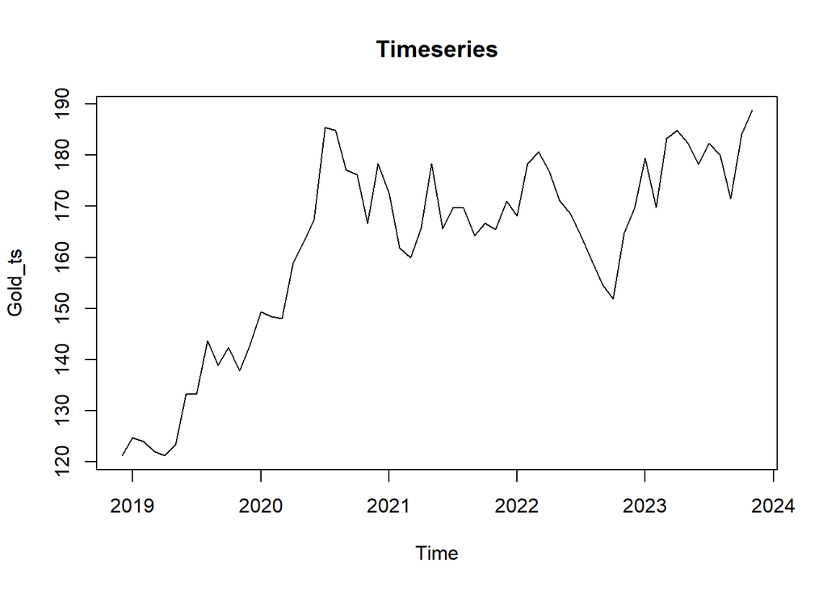

```r
Gold_Raw <- GOLD$Close
Gold_ts <- ts(Gold_Raw, frequency = 12, start = c(2018,12))
plot(Gold_ts,main = "Timeseries")
```

#### Show a time series plot

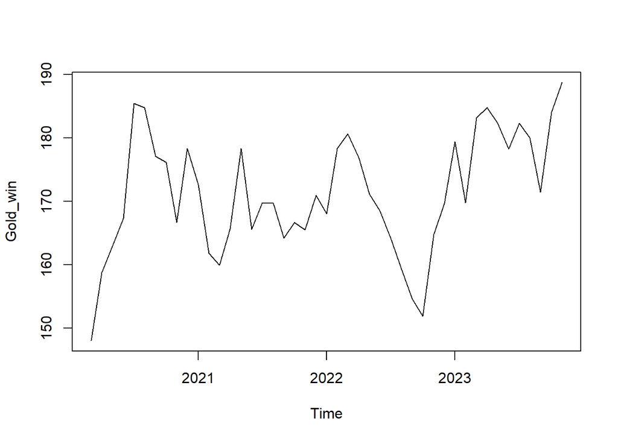

```r
Gold_win <- window(Gold_ts, start = c(2020,03))
plot(Gold_win)
```

#### Please summaries your observations of the times series plot

- We can see that from March 2020 the price of gold started to increase rapidly
- Yearly the price of gold was increasing and decreasing but from 2022 Feb the prices got drop till Nov and there was rise again from that period
- The current value of gold is found to be maximum compared to last 5 years

## Central Tendency

#### What are the min, max, mean, median, 1st and 3rd Quartile values of the times series?

```r
summary(Gold_win)
```

```
##    Min. 1st Qu.  Median    Mean 3rd Qu.    Max.
##   148.1   165.5   169.8   171.3   178.4   188.8
```

#### Show the box plot

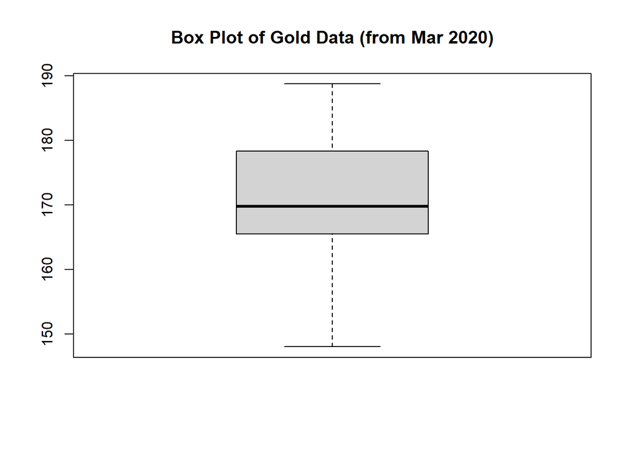

```r
boxplot(Gold_win, main = "Box Plot of Gold Data (from Mar 2020)")
```

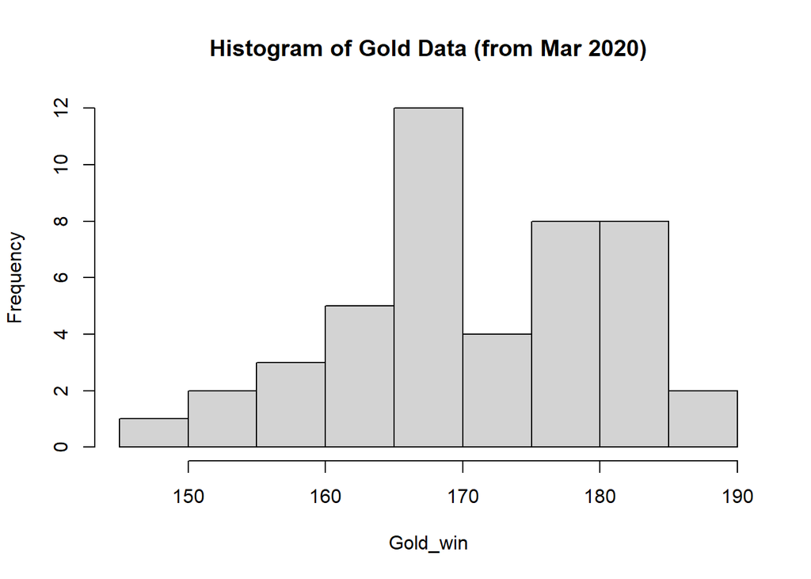

```r
hist(Gold_win, main = "Histogram of Gold Data (from Mar 2020)")
```

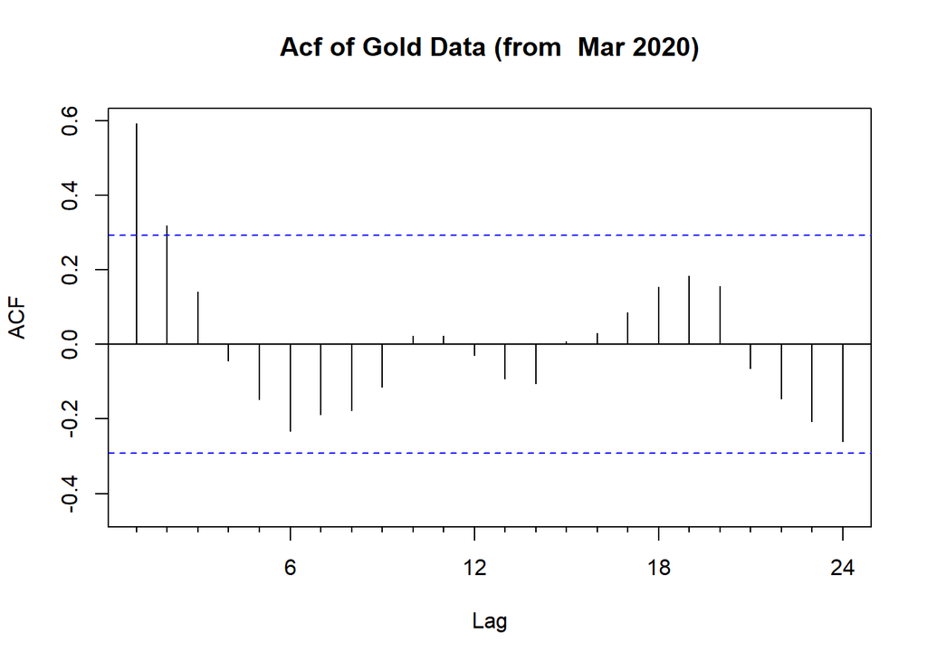

```r
Acf(Gold_win, main = "Acf of Gold Data (from  Mar 2020)")
```

## Decomposition

#### Plot the decomposition of the time series

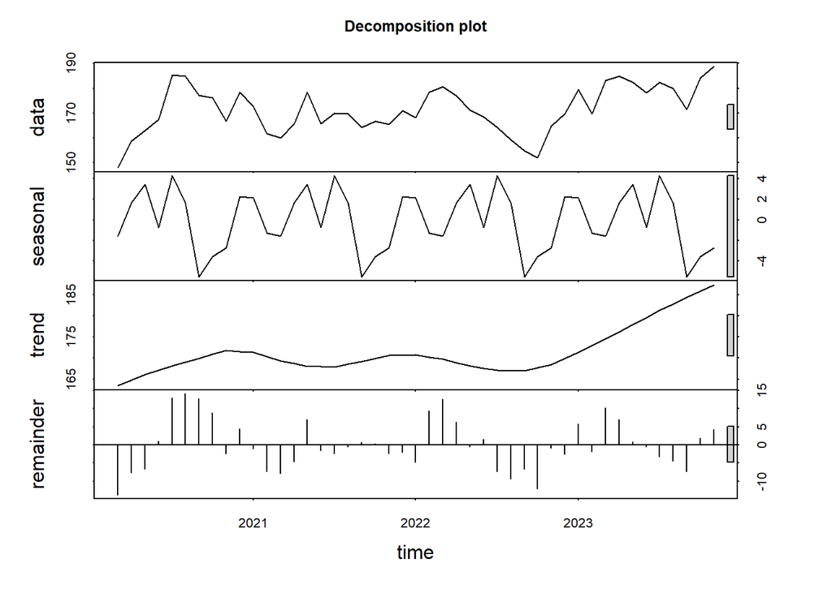

```r
stl_decomp <- stl(Gold_win,s.window ="periodic")
plot(stl_decomp, main = 'Decomposition plot')
```

#### Is the times series seasonal?

- Yes, the times series has a seasonal component.

#### Is the decomposition additive or multiplicative?

```r
decom <- decompose(Gold_win)
decom$type
```

```
## [1] "additive"
```

- The decomposition is additive.
- Because, with as trend increases, we do not see any increase in the seasonality. The seasonality appears to be the same throughout.

#### If seasonal, what are the values of the seasonal monthly indices?

```r
decom$figure
```

```
##  [1]  3.7697035  4.9188731  5.9926231 -0.4707080 -0.5157075 -3.3034194
##  [7] -3.7489095 -5.0151592 -4.9058533  1.9998446  2.2745645 -0.9958520
```

#### Show the plot for time series adjusted for seasonality. Overlay this with the line for actual time series? Does seasonality have big fluctuations to the value of time series?

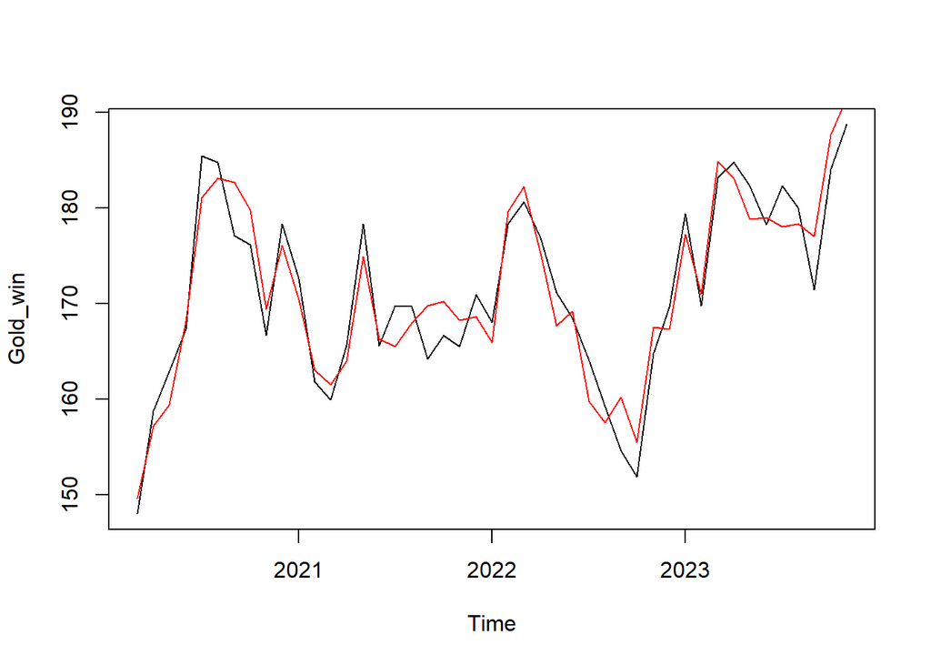

```r
plot(Gold_win)
lines(seasadj(stl_decomp), main = "Seasonally adjusted plot", col="Red")
```

## Naive Method

#### Output

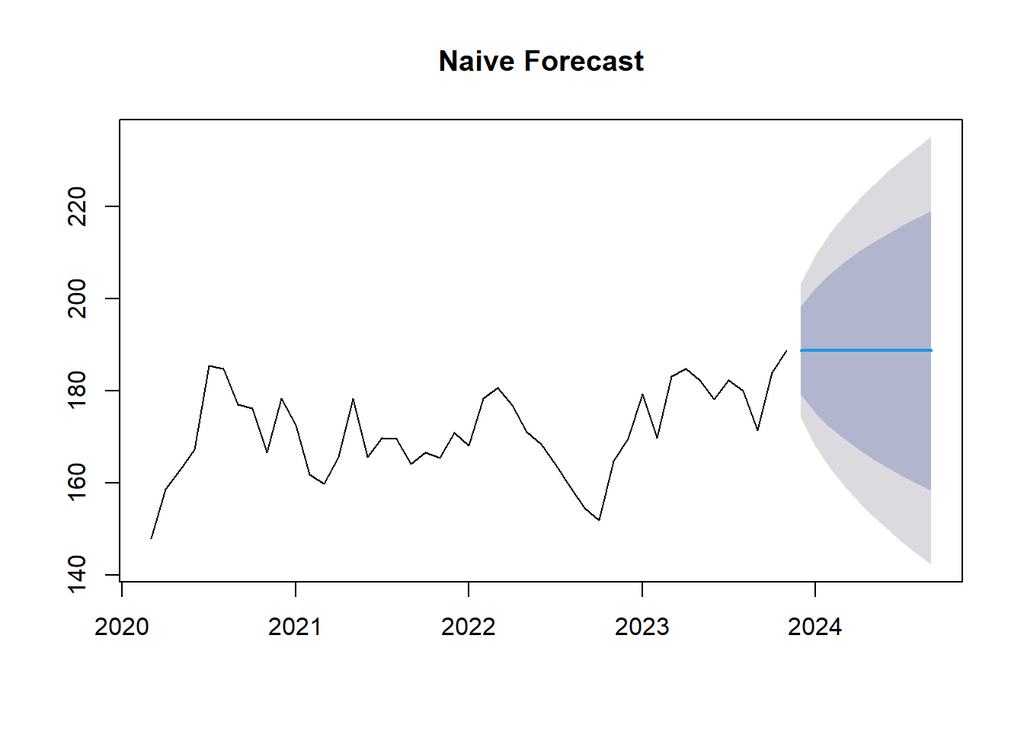

```r
Gold_naive = naive(Gold_win)
plot(Gold_naive, main = "Naive Forecast")
```

#### Perform Residual Analysis for this technique.

###### Do a plot of residuals. What does the plot indicate?

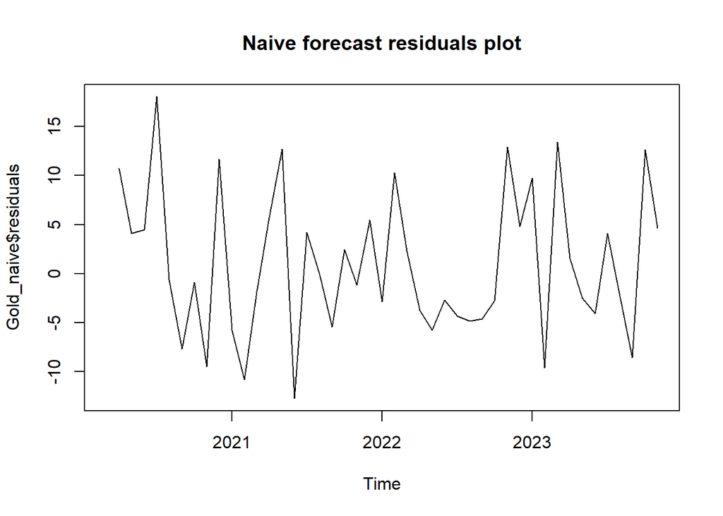

```r
plot(Gold_naive$residuals, main = "Naive forecast residuals plot")
```

* The residuals appear to have seasonality. * Ideally, there shouldn’t have any trend, pattern, or seasonality. * We can test this hypothesis in the coming tests.

###### Do a Histogram plot of residuals. What does the plot indicate?

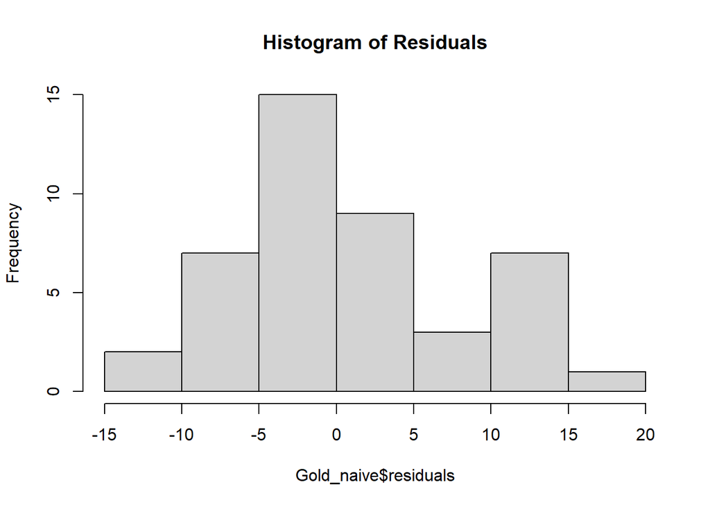

```r
hist(Gold_naive$residuals, main ='Histogram of Residuals')
```

* Should follow a normal distribution in an ideal case. * The histogram does not appears to be normally distributed. One bar has more frequency which disturbs the normal distribution * The values do not have a mean zero. The histogram appears to be skewed on left side.

###### Do a plot of fitted values vs. residuals. What does the plot indicate?

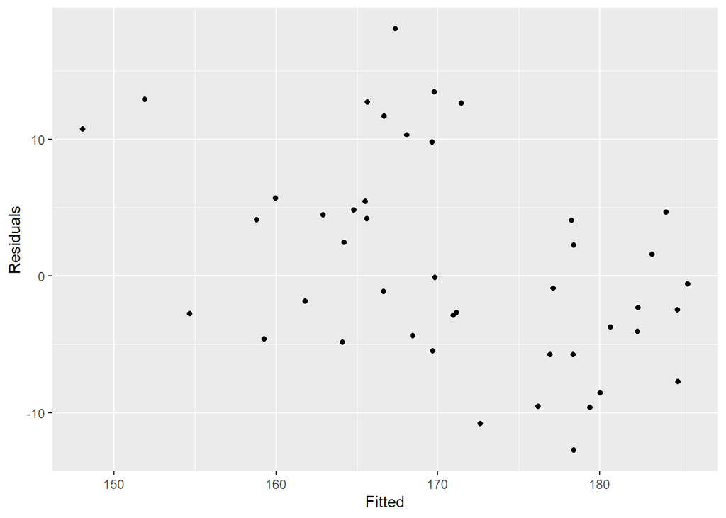

```r
cbind(Fitted = fitted(Gold_naive),
      Residuals=residuals(Gold_naive)) %>%
  as.data.frame() %>%
  ggplot(aes(x=Fitted, y=Residuals)) + geom_point()
```

* The Fitted vs Residuals plot appears to have a random shape.The dots are far from each other which represents low correlation * Also in the errors which means that the variance of the residuals may not be constant.

###### Do a plot of actual values vs. residuals. What does the plot indicate?

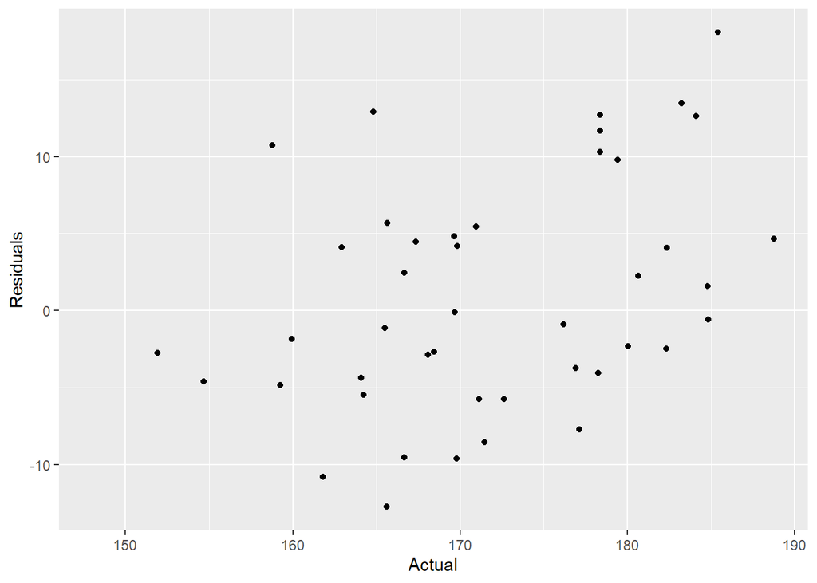

```r
cbind(Actual = Gold_win,
      Residuals=residuals(Gold_naive)) %>%
  as.data.frame() %>%
  ggplot(aes(x=Actual, y=Residuals)) + geom_point()
```

- Similar to the previous plot, The actual vs Residuals plot also appears to be random.The most plots are on the 170 value

###### Do an ACF plot of the residuals? What does this plot indicate?

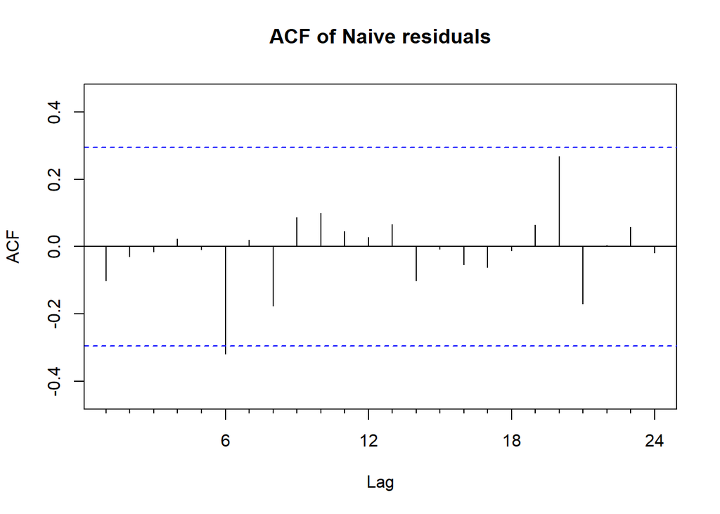

```r
Acf(Gold_naive$residuals, main = "ACF of Naive residuals")
```

* Values of the ACF have crossed the confidence level meaning there is a trend in the residuals and we have missed some variable in our forecast. * Meaning that naive forecast is missing some main variables which we have missed our consideration for the forecast.

## Print the 5 measures of accuracy for this forecasting technique

```r
naive_accuracy <- accuracy(Gold_naive)
naive_accuracy
```

```
##                     ME     RMSE      MAE       MPE     MAPE      MASE
## Training set 0.9249999 7.487287 6.167273 0.4570086 3.581618 0.5552161
##                    ACF1
## Training set -0.1018131
```

### Forecast

###### Time series value for next year. Show table and plot

```r
forecast(Gold_win)
```

```
##          Point Forecast    Lo 80    Hi 80    Lo 95    Hi 95
## Dec 2023       188.1347 178.4740 197.7954 173.3599 202.9095
## Jan 2024       188.1347 175.1669 201.1025 168.3021 207.9672
## Feb 2024       188.1347 172.5463 203.7231 164.2943 211.9751
## Mar 2024       188.1347 170.3068 205.9625 160.8693 215.4000
## Apr 2024       188.1347 168.3188 207.9505 157.8290 218.4404
## May 2024       188.1347 166.5129 209.7565 155.0670 221.2023
## Jun 2024       188.1347 164.8465 211.4228 152.5186 223.7508
## Jul 2024       188.1347 163.2917 212.9776 150.1407 226.1286
## Aug 2024       188.1347 161.8287 214.4407 147.9031 228.3662
## Sep 2024       188.1347 160.4428 215.8265 145.7836 230.4857
## Oct 2024       188.1347 159.1230 217.1463 143.7652 232.5041
## Nov 2024       188.1347 157.8608 218.4086 141.8347 234.4346
## Dec 2024       188.1347 156.6491 219.6203 139.9816 236.2877
## Jan 2025       188.1347 155.4823 220.7870 138.1972 238.0722
## Feb 2025       188.1347 154.3558 221.9135 136.4743 239.7950
## Mar 2025       188.1347 153.2657 223.0037 134.8071 241.4622
## Apr 2025       188.1347 152.2086 224.0607 133.1905 243.0788
## May 2025       188.1347 151.1818 225.0876 131.6201 244.6492
## Jun 2025       188.1347 150.1827 226.0866 130.0922 246.1772
## Jul 2025       188.1347 149.2093 227.0600 128.6034 247.6659
## Aug 2025       188.1347 148.2596 228.0097 127.1510 249.1183
## Sep 2025       188.1347 147.3320 228.9373 125.7324 250.5369
## Oct 2025       188.1347 146.4251 229.8442 124.3454 251.9240
## Nov 2025       188.1347 145.5374 230.7319 122.9878 253.2815
```

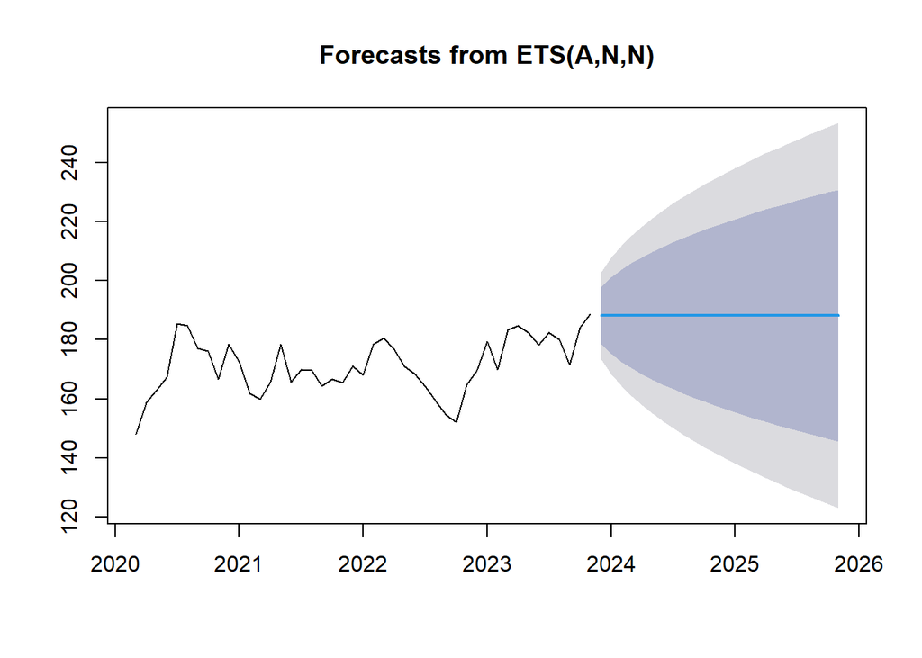

```r
plot(forecast(Gold_win))
```

## Simple Moving Averages

#### Plot the graph for time series

#### Show the Simple Moving average of order 3 on the plot above in Red

#### Show the Simple Moving average of order 6 on the plot above in Blue

#### Show the Simple Moving average of order 9 on the plot above in Green

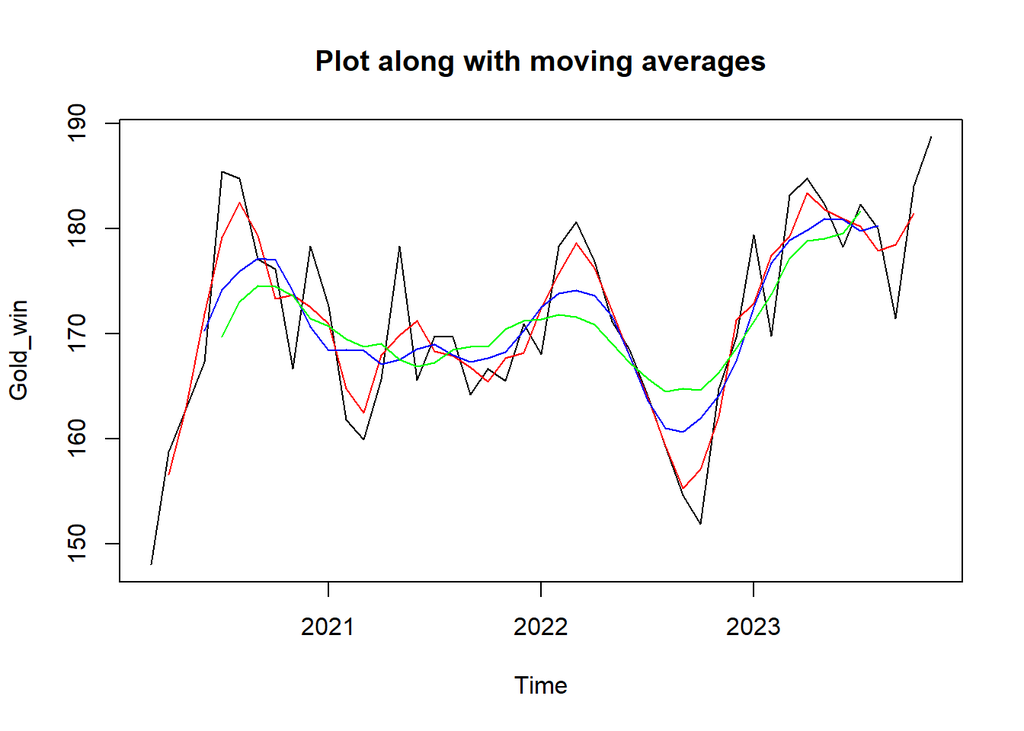

```r
mavg3_forecast = ma(Gold_win,order=3)
mavg6_forecast = ma(Gold_win,order=6)
mavg9_forecast = ma(Gold_win,order=9)
plot(Gold_win, main = "Plot along with moving averages")
lines(mavg3_forecast, col="Red")
lines(mavg6_forecast, col="Blue")
lines(mavg9_forecast, col="Green")
```

* The Red line (order 3) gives the most real data compared to the other two. The higher order averages smoother the plot and do not give the actual values.

#### (Bonus) show the forecast of next 12 months using one of the simple average order that you feel works best for time series

```r
MA3_forecast <- forecast(mavg3_forecast, h = 12)
```

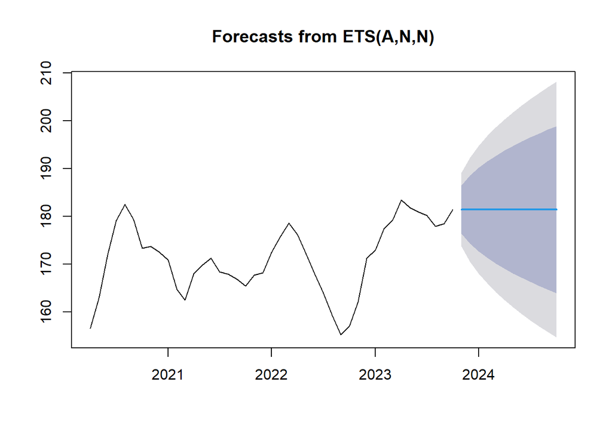

```r
plot(MA3_forecast)
```

#### What are your observations of the plot as the moving average order goes up? * Red(order 3) is compared to be more aaccurate to the real data than other two * The higher order averages smoother the plot and do not give the actual values.

## Simple Smoothing

#### Perform a simple smoothing forecast for next 12 months for the time series.

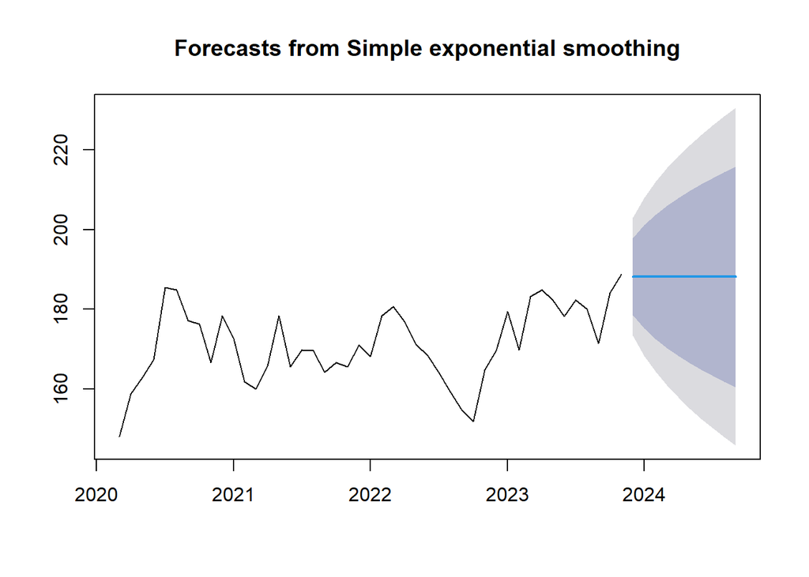

```r
ses_data <- ses(Gold_win)
plot(ses_data)
```

###### What is the value of alpha? What does that value signify? ###### What is the value of initial state? ###### What is the value of sigma? What does the sigma signify? ’

```r
summary(ses_data)
```

```
##
## Forecast method: Simple exponential smoothing
##
## Model Information:
## Simple exponential smoothing
##
## Call:
##  ses(y = Gold_win)
##
##   Smoothing parameters:
##     alpha = 0.8957
##
##   Initial states:
##     l = 149.2253
##
##   sigma:  7.5383
##
##      AIC     AICc      BIC
## 357.0536 357.6390 362.4736
##
## Error measures:
##                     ME     RMSE      MAE       MPE     MAPE      MASE
## Training set 0.9654249 7.368872 6.131368 0.4731164 3.564449 0.5519837
##                     ACF1
## Training set -0.01247993
##
## Forecasts:
##          Point Forecast    Lo 80    Hi 80    Lo 95    Hi 95
## Dec 2023       188.1361 178.4754 197.7968 173.3613 202.9109
## Jan 2024       188.1361 175.1670 201.1052 168.3016 207.9706
## Feb 2024       188.1361 172.5455 203.7266 164.2924 211.9798
## Mar 2024       188.1361 170.3054 205.9668 160.8664 215.4058
## Apr 2024       188.1361 168.3168 207.9553 157.8252 218.4470
## May 2024       188.1361 166.5104 209.7618 155.0625 221.2097
## Jun 2024       188.1361 164.8436 211.4285 152.5133 223.7588
## Jul 2024       188.1361 163.2884 212.9837 150.1349 226.1373
## Aug 2024       188.1361 161.8250 214.4472 147.8967 228.3754
## Sep 2024       188.1361 160.4387 215.8334 145.7767 230.4955
```

- alpha = 0.8957
- In time series forecasting, the smoothing parameter alpha determines the weight assigned to the latest observation in the level component. A higher alpha value, closer to 1.0, indicates a greater emphasis on the most recent data point in updating the level, influencing the forecast *Initial states: l = 149.2253
- Sigma: 7.5383
- Sigma defines the variance in the forecast predicted it represents the standard deviation of the error term, influencing the level of variability considered in the smoothing model. The optimal sigma value should be chosen based on the characteristics of the data, with higher values accommodating greater uncertainty or variability.

##### Perform Residual Analysis for this technique

###### Do a plot of residuals. What does the plot indicate?

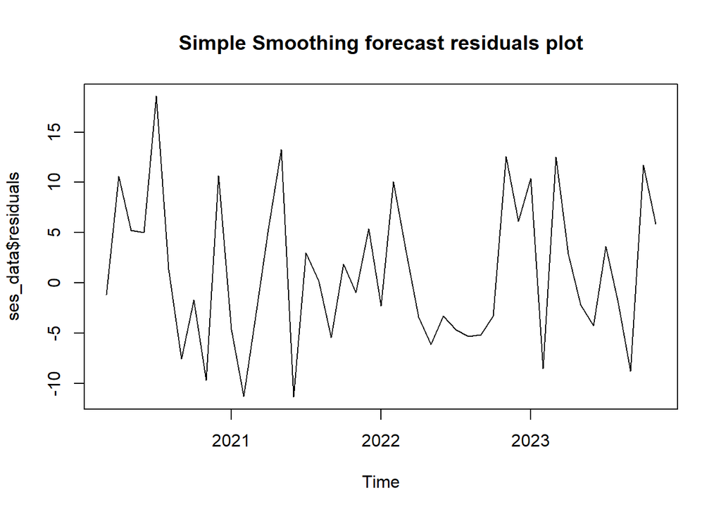

```r
plot(ses_data$residuals, main = "Simple Smoothing forecast residuals plot")
```

- The residuals appear to have seasonality.
- Ideally, there shouldn’t have any trend, pattern, or seasonality.
- We can test this hypothesis in the coming tests.

###### Do a Histogram plot of residuals. What does the plot indicate?

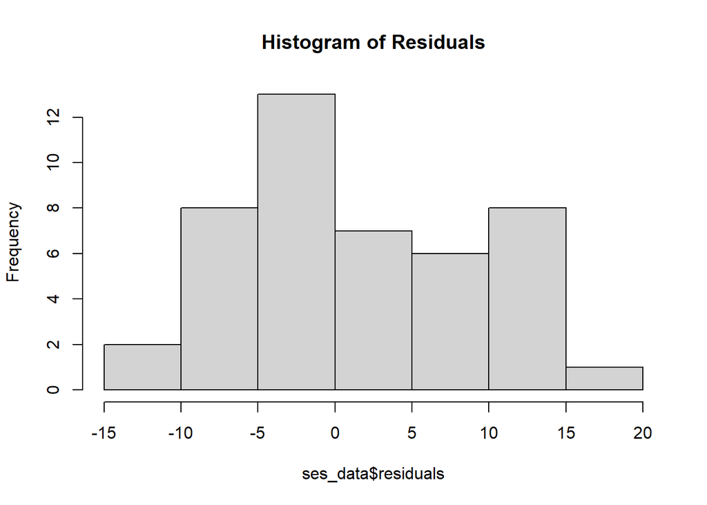

```r
hist(ses_data$residuals, main ='Histogram of Residuals')
```

* Should follow a normal distribution in an ideal case. * The histogram does not appears to be normally distributed. One bar has more frequency which disturbs the normal distribution * The values do not have a mean zero. The histogram appears to be skewed on left side.

###### Do a plot of fitted values vs. residuals. What does the plot indicate?

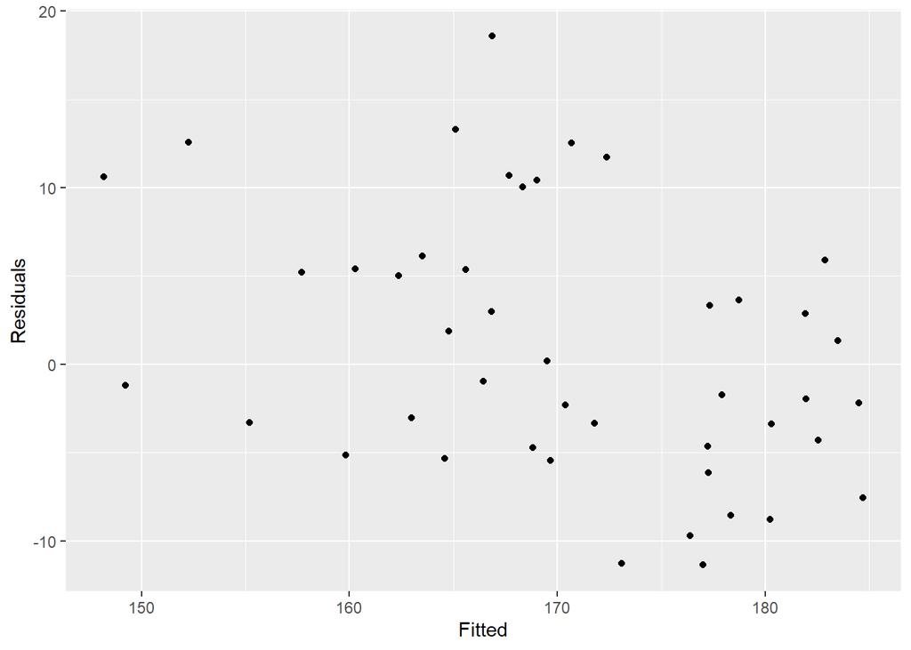

```r
cbind(Fitted = fitted(ses_data),
      Residuals=residuals(ses_data)) %>%
  as.data.frame() %>%
  ggplot(aes(x=Fitted, y=Residuals)) + geom_point()
```

* The Fitted vs Residuals plot appears to have a random shape.

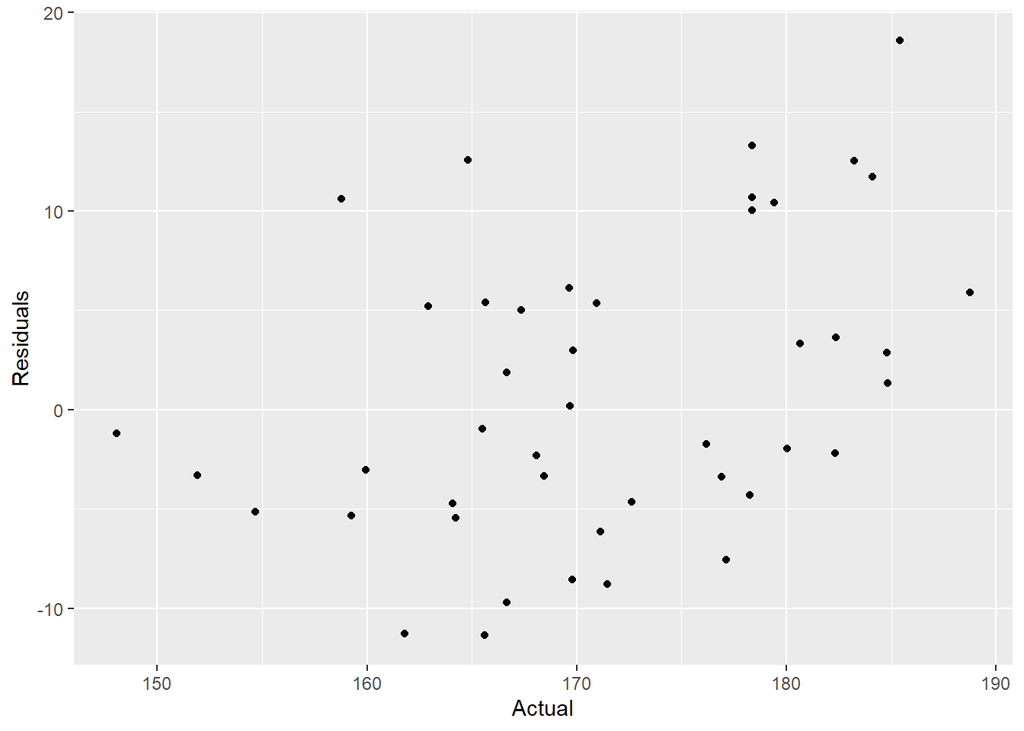

```r
cbind(Actual = Gold_win,
      Residuals=residuals(ses_data)) %>%
  as.data.frame() %>%
  ggplot(aes(x=Actual, y=Residuals)) + geom_point()
```

- Similar to the previous plot, The actual vs Residuals plot also appears to be randomly .

###### Do an ACF plot of the residuals? What does this plot indicate?

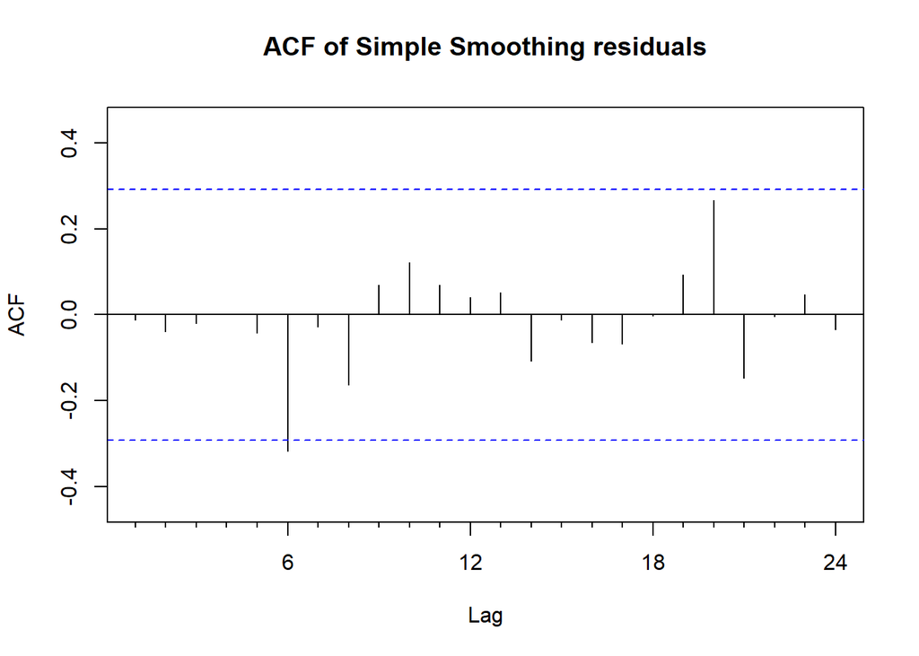

```r
Acf(ses_data$residuals, main = "ACF of Simple Smoothing residuals")
```

* Values of the Acf have crossed the confidence level meaning there is a trend in the residuals and we have missed some variable in our forecast. * The Acf values also show seasonality in the plot and we missed this variable too. * Meaning that simple smoothing forecast is missing some main variables which we have missed our consideration for the forecast.

## Print the 5 measures of accuracy for this forecasting technique

```r
ses_accuracy <- accuracy(ses_data)
ses_accuracy
```

```
##                     ME     RMSE      MAE       MPE     MAPE      MASE
## Training set 0.9654249 7.368872 6.131368 0.4731164 3.564449 0.5519837
##                     ACF1
## Training set -0.01247993
```

### Forecast

###### Time series value for next year. Show table and plot

```r
forecast(ses_data)
```

```
##          Point Forecast    Lo 80    Hi 80    Lo 95    Hi 95
## Dec 2023       188.1361 178.4754 197.7968 173.3613 202.9109
## Jan 2024       188.1361 175.1670 201.1052 168.3016 207.9706
## Feb 2024       188.1361 172.5455 203.7266 164.2924 211.9798
## Mar 2024       188.1361 170.3054 205.9668 160.8664 215.4058
## Apr 2024       188.1361 168.3168 207.9553 157.8252 218.4470
## May 2024       188.1361 166.5104 209.7618 155.0625 221.2097
## Jun 2024       188.1361 164.8436 211.4285 152.5133 223.7588
## Jul 2024       188.1361 163.2884 212.9837 150.1349 226.1373
## Aug 2024       188.1361 161.8250 214.4472 147.8967 228.3754
## Sep 2024       188.1361 160.4387 215.8334 145.7767 230.4955
```

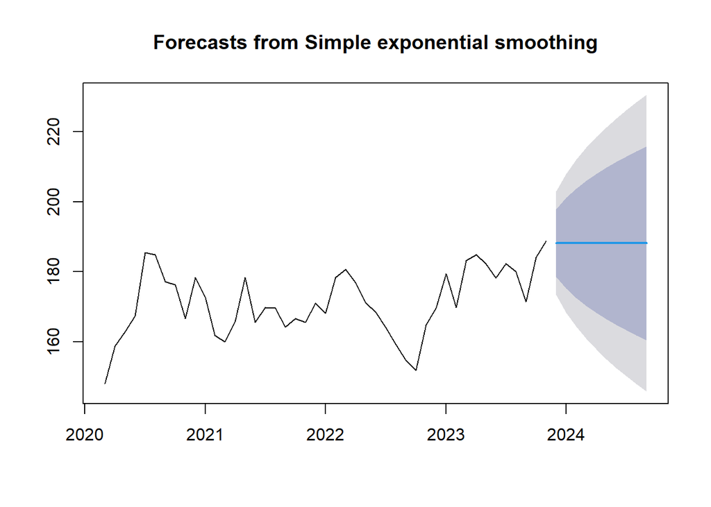

```r
plot(forecast(ses_data))
```

#### Summarize this forecasting technique

###### What does it predict the value of time series will be in one year?

- Sep 2024- 188.1361

###### Other observation

- The data exhibits a discernible upward trend, making simple smoothing forecasts less suitable.
- Exploring alternative forecasting methods is advisable, evaluating their performance based on lower error values compared to simple smoothing.

## HoltWinters

#### Perform Holt-Winters forecast for next 12 months for the time series.

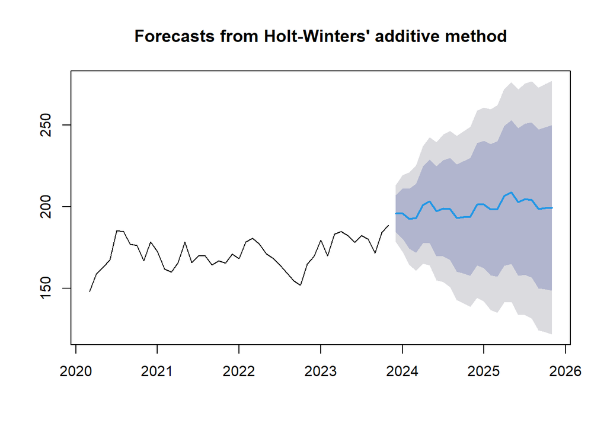

```r
HW_forecast <- hw(Gold_win, seasonal = "additive")
plot(forecast(HW_forecast))
```

```r
attributes(HW_forecast)
```

```
## $names
##  [1] "model"     "mean"      "level"     "x"         "upper"     "lower"
##  [7] "fitted"    "method"    "series"    "residuals"
##
## $class
## [1] "forecast"
```

```r
hw_add <- forecast(HW_forecast)
```

- Here, additive Holtwinters method is considered.
- The absence of an increasing trend in seasonality indicates an additive time series nature, as the seasonal patterns are not compounding with the trend.

###### What is the value of alpha? What does that value signify?

###### What is the value of beta? What does that value signify?

###### What is the value of gamma? What does that value signify?

###### What is the value of initial states for the level, trend and seasonality? What do these values signify?

###### What is the value of sigma? What does the sigma signify?

```r
hw_add$model
```

```
## Holt-Winters' additive method
##
## Call:
##  hw(y = Gold_win, seasonal = "additive")
##
##   Smoothing parameters:
##     alpha = 0.9058
##     beta  = 0.0002
##     gamma = 0.0001
##
##   Initial states:
##     l = 167.6261
##     b = 0.4632
##     s = -2.1684 1.4705 2.0528 -5.1915 -5.0245 -4.9942
##            1.0415 1.8817 0.567 7.1953 5.402 -2.2321
##
##   sigma:  8.8842
##
##      AIC     AICc      BIC
## 382.1127 404.7793 412.8259
```

- Alpha = 0.9058 . Alpha specifies the coefficient for the level smoothing in HoltWinters.
- Beta = 0.0002. Beta specifies the coefficient for the trend smoothing in HoltWinters.
- Gamma = 0.0001. Gamma specifies the coefficient for the seasonal smoothing in HoltWinters.
- Values 1.0 means that the latest value has highest weight.
- Initial states: l = 167.6261 b = 0.4632 s = -2.1684 1.4705 2.0528 -5.1915 -5.0245 -4.9942 1.0415 1.8817 0.567 7.1953 5.402 -2.2321
- sigma: 8.8842. Sigma defines the variance of the forecast values.

#### Perform Residual Analysis for this technique.

###### Do a plot of residuals. What does the plot indicate?

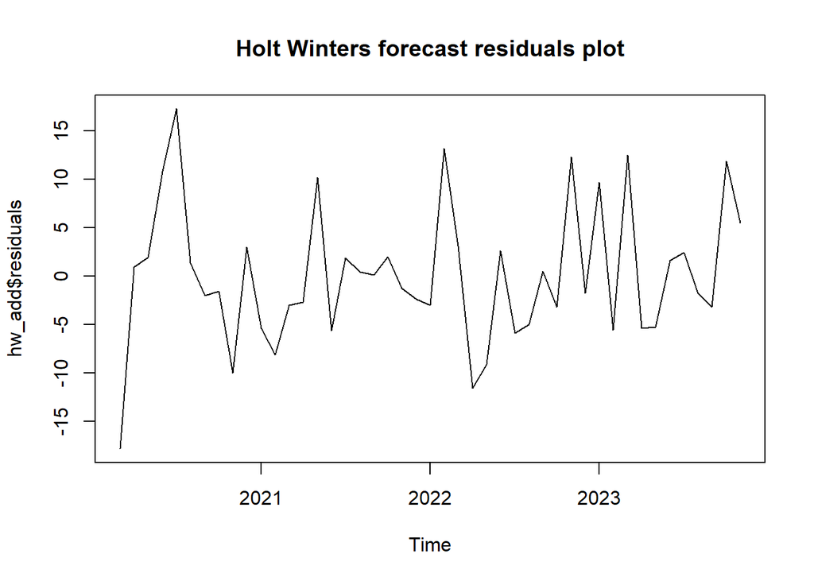

```r
plot(hw_add$residuals, main = "Holt Winters forecast residuals plot")
```

* The residuals appear to be random. * The residuals seem to have a mean at zero. * HoltWinters seems to be the best forecast comparing to the others. * We can test this hypothesis in the coming tests.

###### Do a Histogram plot of residuals. What does the plot indicate?

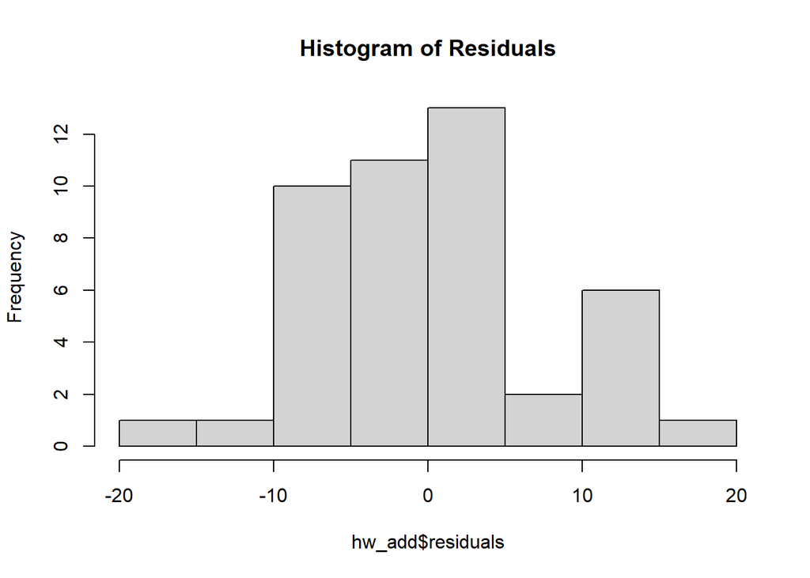

```r
hist(hw_add$residuals, main ='Histogram of Residuals')
```

###### Do a plot of fitted values vs. residuals. What does the plot indicate?

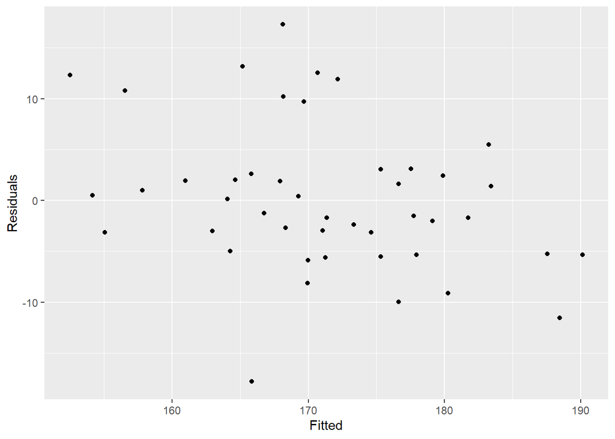

```r
cbind(Fitted = fitted(hw_add),
      Residuals=residuals(hw_add)) %>%
  as.data.frame() %>%
  ggplot(aes(x=Fitted, y=Residuals)) + geom_point()
```

###### Do a plot of actual values vs. residuals. What does the plot indicate?

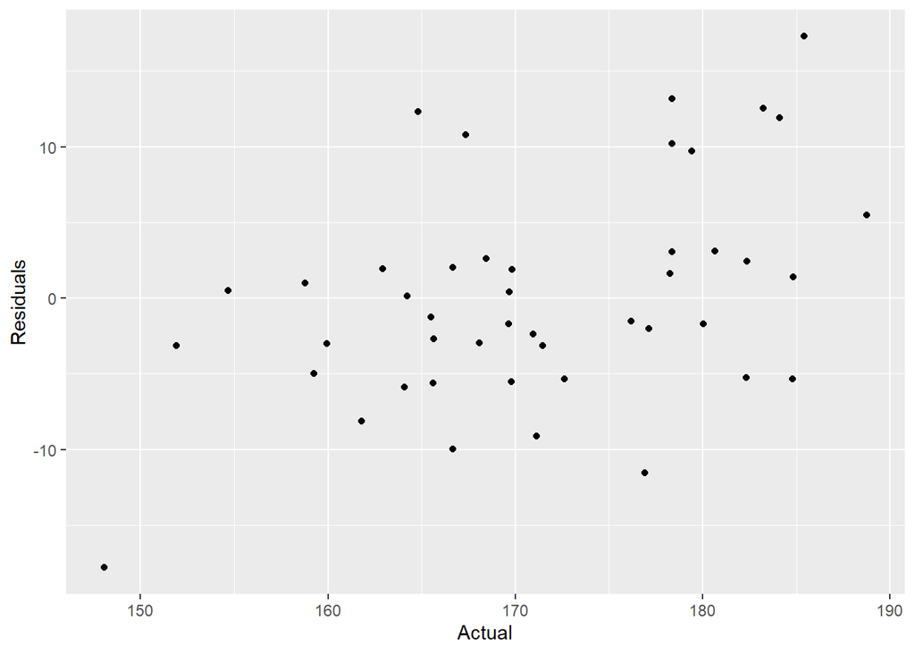

```r
cbind(Actual = Gold_win,
      Residuals=residuals(hw_add)) %>%
  as.data.frame() %>%
  ggplot(aes(x=Actual, y=Residuals)) + geom_point()
```

###### Do an ACF plot of the residuals? What does this plot indicate?

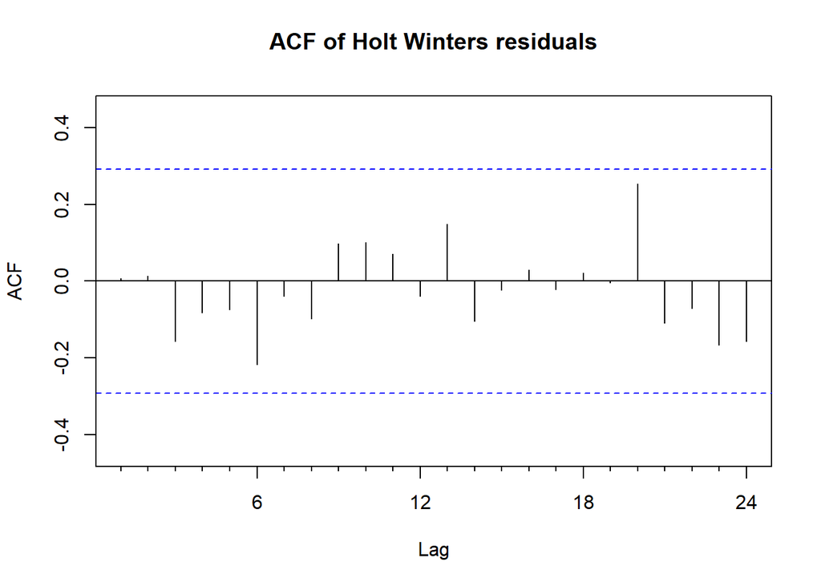

```r
Acf(hw_add$residuals, main = "ACF of Holt Winters residuals")
```

* In the Acf plot, none of the values crossed the confidence levels. It appears to be white noice. * This signifies that the forecast is a good forecast.

## Print the 5 measures of accuracy for this forecasting technique

```r
hw_accuracy <- accuracy(hw_add)
hw_accuracy
```

```
##                     ME     RMSE      MAE         MPE     MAPE      MASE
## Training set 0.1229671 7.131968 5.461529 -0.03578919 3.183366 0.4916806
##                     ACF1
## Training set 0.006897143
```

### Forecast

###### Time series value for next year. Show table and plot

```r
forecast(hw_add)
```

```
##          Point Forecast    Lo 80    Hi 80    Lo 95    Hi 95
## Dec 2023       195.9413 184.5558 207.3268 178.5286 213.3539
## Jan 2024       195.8234 180.4603 211.1864 172.3275 219.3192
## Feb 2024       192.6482 174.1426 211.1538 164.3464 220.9500
## Mar 2024       193.0479 171.8600 214.2358 160.6438 225.4520
## Apr 2024       201.1443 177.5766 224.7119 165.1007 237.1879
## May 2024       203.4039 177.6749 229.1328 164.0548 242.7529
## Jun 2024       197.2412 169.5182 224.9641 154.8426 239.6397
## Jul 2024       199.0208 169.4373 228.6043 153.7768 244.2648
## Aug 2024       198.6418 167.3075 229.9761 150.7201 246.5635
## Sep 2024       193.0702 160.0773 226.0632 142.6118 243.5286
## Oct 2024       193.5058 158.9332 228.0785 140.6315 246.3802
## Nov 2024       193.8026 157.7188 229.8864 138.6172 248.9880
## Dec 2024       201.5099 163.9748 239.0450 144.1049 258.9149
## Jan 2025       201.3919 162.4596 240.3243 141.8500 260.9339
## Feb 2025       198.2168 157.9351 238.4985 136.6112 259.8223
## Mar 2025       198.6165 157.0288 240.2042 135.0136 262.2194
## Apr 2025       206.7129 163.8585 249.5672 141.1727 272.2530
## May 2025       208.9725 164.8874 253.0576 141.5501 276.3948
## Jun 2025       202.8097 157.5269 248.0925 133.5557 272.0638
## Jul 2025       204.5894 158.1393 251.0394 133.5502 275.6286
## Aug 2025       204.2104 156.6213 251.7994 131.4292 276.9915
## Sep 2025       198.6388 149.9370 247.3406 124.1558 273.1218
## Oct 2025       199.0744 149.2843 248.8645 122.9271 275.2218
## Nov 2025       199.3712 148.5157 250.2266 121.5945 277.1479
```

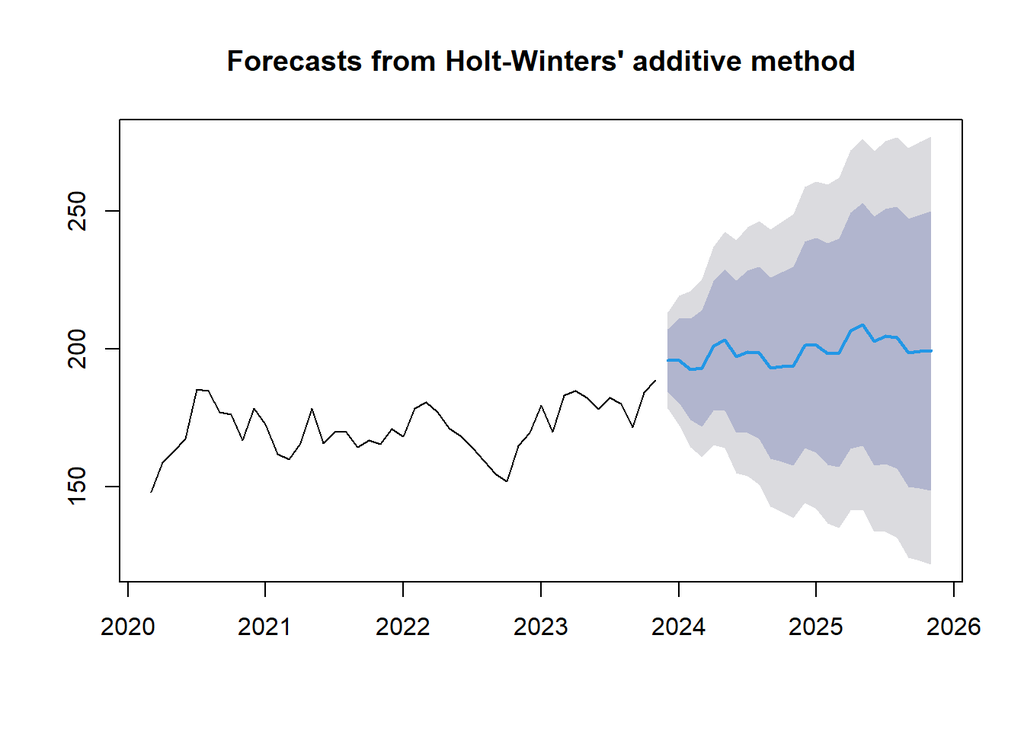

```r
plot(forecast(hw_add))
```

#### Summarize this forecasting technique

###### How good is the accuracy?

- The ME, RMSE values are quite low compared to any of our previous forecasts.
- Holwinters is a better forecast compared to naive and simple smoothing.

###### What does it predict the value of time series will be in one year?

- Nov 2024 - 193.8026

###### Other observation

- Holtwinters appears to be the better forecast considering all the previous forecast methods.
- However, this forecast is not found to be best until we test ARIMA Model.

##ARIMA MODEL ####Is Time Series data Stationary? How did you verify?

```r
adf.test(Gold_win)
```

```
##
##  Augmented Dickey-Fuller Test
##
## data:  Gold_win
## Dickey-Fuller = -2.774, Lag order = 3, p-value = 0.2668
## alternative hypothesis: stationary
```

```r
kpss.test(Gold_win)
```

```
##
##  KPSS Test for Level Stationarity
##
## data:  Gold_win
## KPSS Level = 0.26589, Truncation lag parameter = 3, p-value = 0.1
```

*ADF test says differences is required if p-value is > 0.05 The null hypothesis of the ADF test is that the data is non-stationary. The p-value is compared to a significance level (commonly 0.05). In this case, the p-value is 0.2668, which is greater than 0.05.

*Kipps test says differences is required if p-value is < 0.05 The null hypothesis of the KPSS test is that the data is stationary around a deterministic trend. The p-value is compared to a significance level (commonly 0.05). In this case, the p-value is 0.1, which is greater than 0.05

#### How many differences are needed to make it stationary?

```r
nsdiffs(Gold_win)
```

```
## [1] 0
```

####Is Seasonality component needed? *No

####Plot the Time Series chart of the differenced series. ####Plot the ACF and PACF plot of the differenced series.

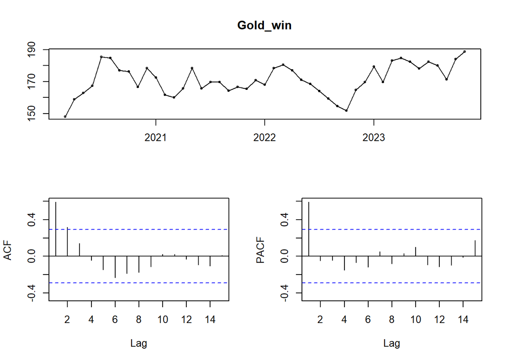

```r
tsdisplay(Gold_win)
```

####Based on the ACF and PACF, which are the possible ARIMA model possible?

```r
#Find out the best ARIMA Model for the time series data set
auto_fit <- auto.arima(Gold_win, trace=TRUE, stepwise = FALSE, approximation = FALSE)
```

```
##
##  ARIMA(0,0,0)            with zero mean     : 592.85
##  ARIMA(0,0,0)            with non-zero mean : 334.4743
##  ARIMA(0,0,0)(0,0,1)[12] with zero mean     : Inf
##  ARIMA(0,0,0)(0,0,1)[12] with non-zero mean : 335.9951
##  ARIMA(0,0,0)(1,0,0)[12] with zero mean     : Inf
##  ARIMA(0,0,0)(1,0,0)[12] with non-zero mean : 336.7044
##  ARIMA(0,0,0)(1,0,1)[12] with zero mean     : Inf
##  ARIMA(0,0,0)(1,0,1)[12] with non-zero mean : Inf
##  ARIMA(0,0,1)            with zero mean     : Inf
##  ARIMA(0,0,1)            with non-zero mean : 318.5816
##  ARIMA(0,0,1)(0,0,1)[12] with zero mean     : Inf
##  ARIMA(0,0,1)(0,0,1)[12] with non-zero mean : 320.7957
##  ARIMA(0,0,1)(1,0,0)[12] with zero mean     : Inf
##  ARIMA(0,0,1)(1,0,0)[12] with non-zero mean : 320.9326
##  ARIMA(0,0,1)(1,0,1)[12] with zero mean     : Inf
##  ARIMA(0,0,1)(1,0,1)[12] with non-zero mean : Inf
##  ARIMA(0,0,2)            with zero mean     : Inf
##  ARIMA(0,0,2)            with non-zero mean : 315.7019
##  ARIMA(0,0,2)(0,0,1)[12] with zero mean     : Inf
##  ARIMA(0,0,2)(0,0,1)[12] with non-zero mean : 318.1709
##  ARIMA(0,0,2)(1,0,0)[12] with zero mean     : Inf
##  ARIMA(0,0,2)(1,0,0)[12] with non-zero mean : 318.1945
##  ARIMA(0,0,2)(1,0,1)[12] with zero mean     : Inf
##  ARIMA(0,0,2)(1,0,1)[12] with non-zero mean : Inf
##  ARIMA(0,0,3)            with zero mean     : Inf
##  ARIMA(0,0,3)            with non-zero mean : 316.9002
##  ARIMA(0,0,3)(0,0,1)[12] with zero mean     : Inf
##  ARIMA(0,0,3)(0,0,1)[12] with non-zero mean : 319.5721
##  ARIMA(0,0,3)(1,0,0)[12] with zero mean     : Inf
##  ARIMA(0,0,3)(1,0,0)[12] with non-zero mean : 319.5721
##  ARIMA(0,0,3)(1,0,1)[12] with zero mean     : Inf
##  ARIMA(0,0,3)(1,0,1)[12] with non-zero mean : Inf
##  ARIMA(0,0,4)            with zero mean     : Inf
##  ARIMA(0,0,4)            with non-zero mean : 319.0443
##  ARIMA(0,0,4)(0,0,1)[12] with zero mean     : Inf
##  ARIMA(0,0,4)(0,0,1)[12] with non-zero mean : 321.8288
##  ARIMA(0,0,4)(1,0,0)[12] with zero mean     : Inf
##  ARIMA(0,0,4)(1,0,0)[12] with non-zero mean : Inf
##  ARIMA(0,0,5)            with zero mean     : Inf
```

[output cut: 72 more lines]

```
##  ARIMA(3,0,2)            with non-zero mean : Inf
##  ARIMA(4,0,0) with zero mean     : Inf
##  ARIMA(4,0,0)            with non-zero mean : 317.7142
##  ARIMA(4,0,0)(0,0,1)[12] with zero mean     : Inf
##  ARIMA(4,0,0)(0,0,1)[12] with non-zero mean : 320.5301
##  ARIMA(4,0,0)(1,0,0)[12] with zero mean     : Inf
##  ARIMA(4,0,0)(1,0,0)[12] with non-zero mean : 320.5302
##  ARIMA(4,0,1)            with zero mean     : Inf
##  ARIMA(4,0,1)            with non-zero mean : Inf
##  ARIMA(5,0,0) with zero mean     : Inf
##  ARIMA(5,0,0)            with non-zero mean : 319.3785
##
##
##
##  Best model: ARIMA(1,0,0)            with non-zero mean
```

*Best model: ARIMA(1,0,0)

####Show the AIC, BIC and Sigma^2 for the possible models? ####Based on the above AIC, BIC and Sigma^2 values, which model will you select? #### What is the final formula for ARIMA with the coefficients?

```r
auto_fit
```

```
## Series: Gold_win
## ARIMA(1,0,0) with non-zero mean
##
## Coefficients:
##          ar1      mean
##       0.7233  171.0105
## s.e.  0.1192    3.6198
##
## sigma^2 = 52.63:  log likelihood = -152.37
## AIC=310.74   AICc=311.33   BIC=316.16
```

```r
attributes(auto_fit)
```

```
## $names
##  [1] "coef"      "sigma2"    "var.coef"  "mask"      "loglik"    "aic"
##  [7] "arma"      "residuals" "call"      "series"    "code"      "n.cond"
## [13] "nobs"      "model"     "bic"       "aicc"      "x"         "fitted"
##
## $class
## [1] "forecast_ARIMA" "ARIMA"          "Arima"
```

*AIC=310.74* BIC=316.16 *sigma^2 = 52.63* For an ARIMA(1,0,0) model with a non-zero mean, the formula would be: Y(t) =μ+ϕ(1)*Y(t−1)+ε(t)

Y(t)is the observed time series at time t μ is the non-zero mean of the time series. ϕ (1)is the autoregressive coefficient for the first lag. Y(t−1)is the value of the time series at the previous time point. ε(t)is the white noise error term at time t.

####Perform Residual Analysis for this technique. ##### Do a plot of residuals. What does the plot indicate?

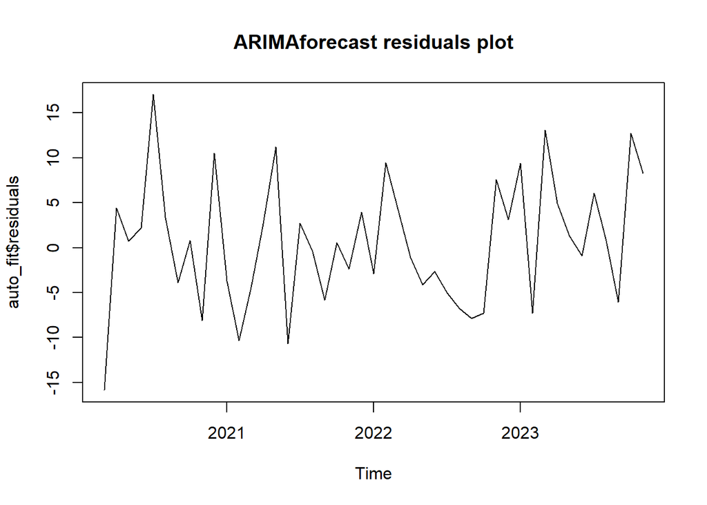

```r
plot(auto_fit$residuals, main = "ARIMAforecast residuals plot")
```

###### Do a Histogram plot of residuals. What does the plot indicate?

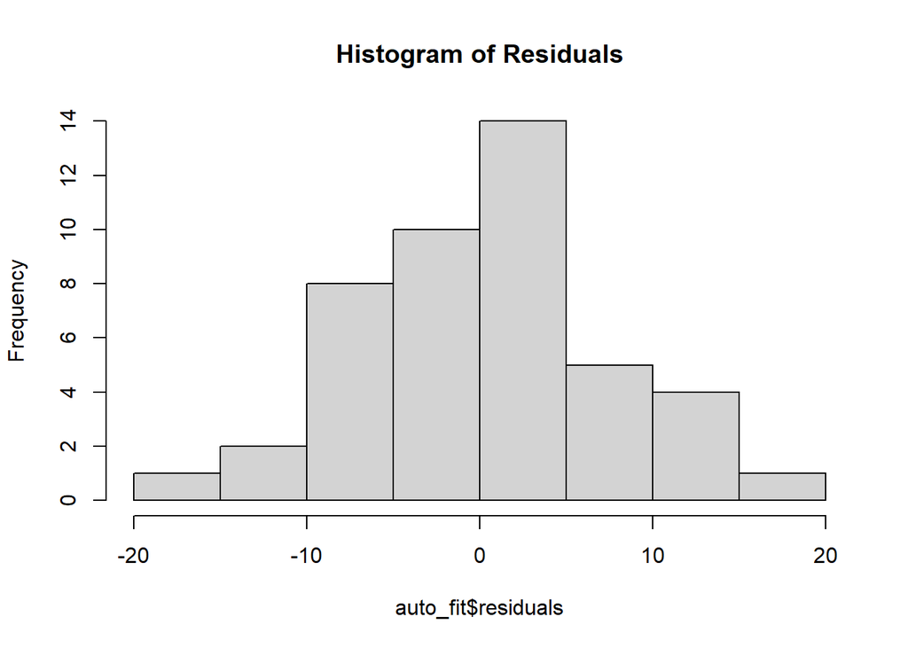

```r
hist(auto_fit$residuals, main ='Histogram of Residuals')
```

##### Do a plot of fitted values vs. residuals. What does the plot indicate?

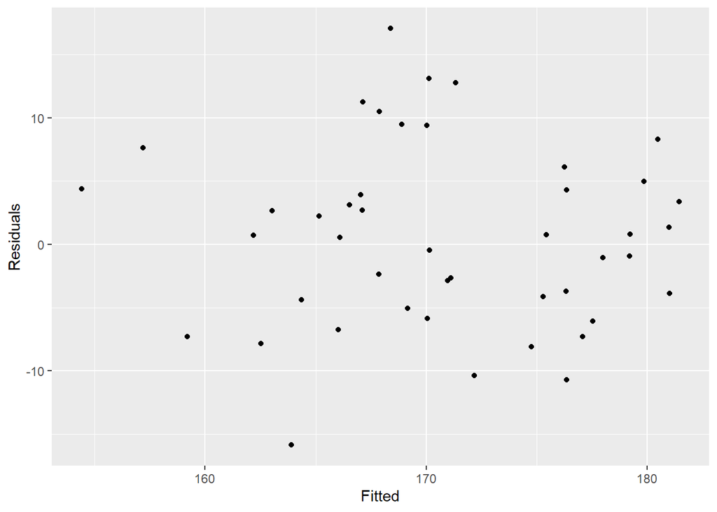

```r
cbind(Fitted = fitted(auto_fit),
      Residuals=residuals(auto_fit)) %>%
  as.data.frame() %>%
  ggplot(aes(x=Fitted, y=Residuals)) + geom_point()
```

##### Do a plot of actual values vs. residuals. What does the plot indicate?

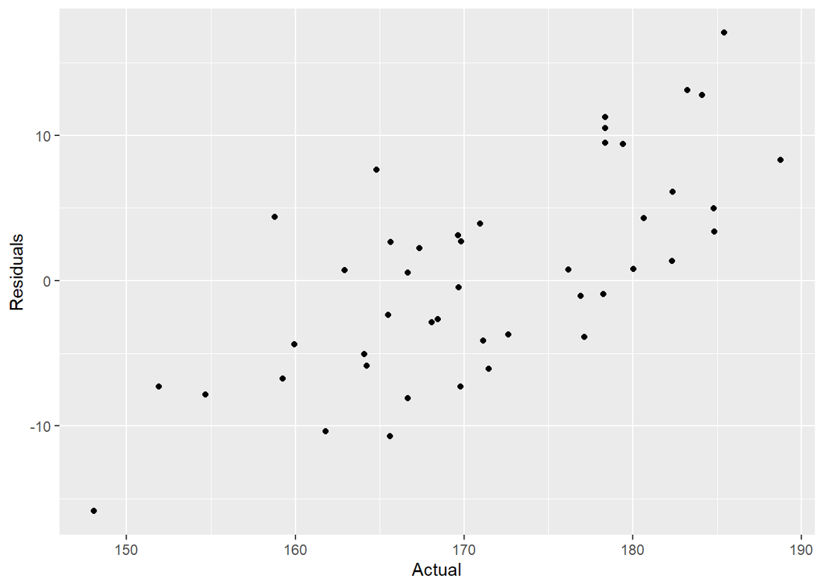

```r
cbind(Actual = Gold_win,
      Residuals=residuals(auto_fit)) %>%
  as.data.frame() %>%
  ggplot(aes(x=Actual, y=Residuals)) + geom_point()
```

##### Do an ACF plot of the residuals? What does this plot indicate?

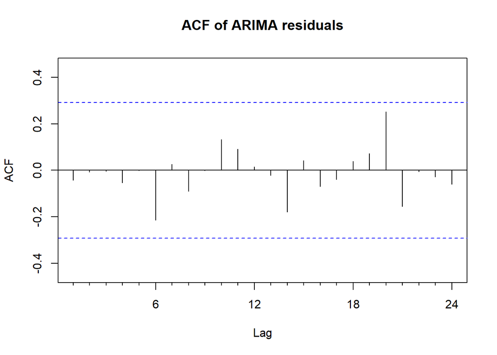

```r
Acf(auto_fit$residuals, main = "ACF of ARIMA residuals")
```

####Print the 5 measures of accuracy for this forecasting technique.

```r
ARIMA_accuracy <- accuracy(auto_fit)
ARIMA_accuracy
```

```
##                     ME     RMSE      MAE       MPE     MAPE      MASE
## Training set 0.5269589 7.091372 5.755705 0.1430252 3.371365 0.5181642
##                     ACF1
## Training set -0.04232878
```

###Forecast #### Next one year. Show table and plot ### Next two years. Show table and plot

```r
forecast(auto_fit)
```

```
##          Point Forecast    Lo 80    Hi 80    Lo 95    Hi 95
## Dec 2023       183.8415 174.5446 193.1384 169.6231 198.0599
## Jan 2024       180.2912 168.8172 191.7651 162.7433 197.8390
## Feb 2024       177.7232 165.2610 190.1854 158.6638 196.7825
## Mar 2024       175.8658 162.9165 188.8151 156.0616 195.6700
## Apr 2024       174.5223 161.3254 187.7192 154.3394 194.7053
## May 2024       173.5506 160.2260 186.8752 153.1723 193.9289
## Jun 2024       172.8477 159.4568 186.2387 152.3680 193.3275
## Jul 2024       172.3394 158.9138 185.7649 151.8068 192.8720
## Aug 2024       171.9717 158.5281 185.4153 151.4115 192.5319
## Sep 2024       171.7057 158.2527 185.1587 151.1311 192.2803
## Oct 2024       171.5133 158.0554 184.9713 150.9312 192.0955
## Nov 2024       171.3742 157.9137 184.8347 150.7881 191.9603
## Dec 2024       171.2736 157.8117 184.7354 150.6854 191.8617
## Jan 2025       171.2008 157.7382 184.6634 150.6115 191.7900
## Feb 2025       171.1481 157.6851 184.6111 150.5583 191.7379
## Mar 2025       171.1100 157.6469 184.5732 150.5199 191.7001
## Apr 2025       171.0825 157.6192 184.5457 150.4922 191.6728
## May 2025       171.0626 157.5992 184.5259 150.4722 191.6529
## Jun 2025       171.0481 157.5848 184.5115 150.4577 191.6385
## Jul 2025       171.0377 157.5744 184.5011 150.4473 191.6281
## Aug 2025       171.0302 157.5668 184.4935 150.4397 191.6206
## Sep 2025       171.0247 157.5614 184.4881 150.4343 191.6152
## Oct 2025       171.0208 157.5574 184.4842 150.4303 191.6112
## Nov 2025       171.0179 157.5546 184.4813 150.4275 191.6084
```

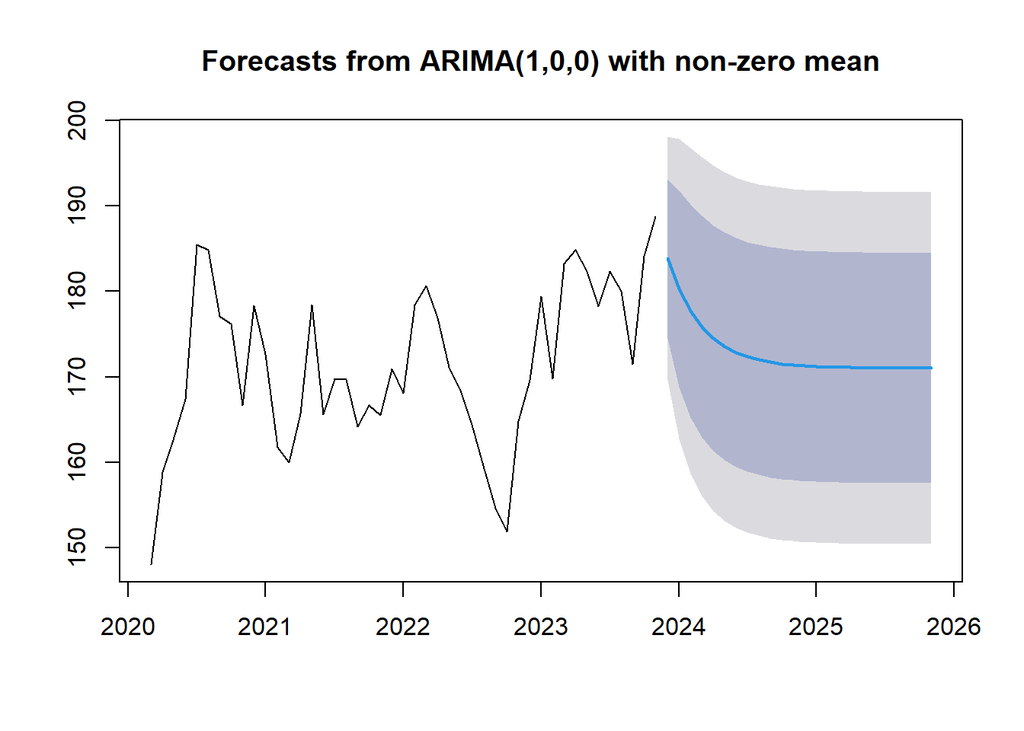

```r
plot(forecast(auto_fit))
```

####Summarize this forecasting technique

####What does it predict time series will be in one year and next two years? *Nov 2024 171.3742* Nov 2025 171.0179

## Accuracy Summary

#### Show a table of all the forecast method above with their accuracy measures

```r
accuracy_table <- data.frame(
  Method = c("Naive", "Simple Smoothing", "Holt-Winters","ARIMA MODEL"),
  ME = c(naive_accuracy[1, "ME"], ses_accuracy[1, "ME"], hw_accuracy[1, "ME"],ARIMA_accuracy[1, "ME"]),
  MAE = c(naive_accuracy[1, "MAE"], ses_accuracy[1, "MAE"], hw_accuracy[1, "MAE"],ARIMA_accuracy[1, "MAE"]),
  MASE = c(naive_accuracy[1, "MASE"], ses_accuracy[1, "MASE"], hw_accuracy[1, "MASE"],ARIMA_accuracy[1, "MASE"]),
  RMSE = c(naive_accuracy[1, "RMSE"], ses_accuracy[1, "RMSE"], hw_accuracy[1, "RMSE"],ARIMA_accuracy[1, "RMSE"]),
  MAPE = c(naive_accuracy[1, "MAPE"], ses_accuracy[1, "MAPE"], hw_accuracy[1, "MAPE"],ARIMA_accuracy[1, "MAPE"])
)

print(accuracy_table)
```

```
##             Method        ME      MAE      MASE     RMSE     MAPE
## 1            Naive 0.9249999 6.167273 0.5552161 7.487287 3.581618
## 2 Simple Smoothing 0.9654249 6.131368 0.5519837 7.368872 3.564449
## 3     Holt-Winters 0.1229671 5.461529 0.4916806 7.131968 3.183366
## 4      ARIMA MODEL 0.5269589 5.755705 0.5181642 7.091372 3.371365
```

## Conclusion

#### Based on your analysis and forecast above, do you think the value of the time series will increase, decrease or stay flat over the next year? How about next 2 years?

- Based on the analysis and forecast, the time series will increase over the next year and the next 2 years.